Title: Practical Machine Learning Final Project

Introduction

The goal of this project is to predict the manner in which individuals performed barbell lifts using data from accelerometers. The target variable is classe.

Step 1: Setting Up the Environment

- Load Necessary libraries

```r
library("caret")
library("randomForest")
library("rpart")
library("e1071")
```

```r
library("ggplot2")
library("rattle")
library("doParallel")
```

- Load the Data

```r
# Load training and testing data from URLs
training_url <- "https://d396qusza40orc.cloudfront.net/predmachlearn/pml-training.csv"
testing_url <- "https://d396qusza40orc.cloudfront.net/predmachlearn/pml-testing.csv"

training <- read.csv(url(training_url), na.strings = c("NA", "#DIV/0!", ""))
testing <- read.csv(url(testing_url), na.strings = c("NA", "#DIV/0!", ""))
```

Step 2: Data Cleaning and Preprocessing

The dataset contains many columns that are not useful for prediction (e.g., timestamps, row numbers, user names), and many columns contain mostly missing values. We’ll clean this up.

- Remove Columns with Mostly NA Values

```r
# Remove columns with more than 95% NA values
na_threshold <- 0.95
training_clean <- training[, colMeans(is.na(training)) < na_threshold]
testing_clean <- testing[, colMeans(is.na(testing)) < na_threshold]
```

- Remove Non-Predictive Columns

```r
# Drop non-predictive columns (first 5 columns are metadata)
training_clean <- training_clean[, -c(1:5)]
testing_clean <- testing_clean[, -c(1:5)]
```

- Make sure the outcome variable (classe) is a factor:

```r
training_clean$classe <- as.factor(training_clean$classe)
```

- Summary of Current Dataset

```r
str(training_clean)
```

```
## 'data.frame':    19622 obs. of  55 variables:
##  $ new_window          : chr  "no" "no" "no" "no" ...
##  $ num_window          : int  11 11 11 12 12 12 12 12 12 12 ...
##  $ roll_belt           : num  1.41 1.41 1.42 1.48 1.48 1.45 1.42 1.42 1.43 1.45 ...
##  $ pitch_belt          : num  8.07 8.07 8.07 8.05 8.07 8.06 8.09 8.13 8.16 8.17 ...
##  $ yaw_belt            : num  -94.4 -94.4 -94.4 -94.4 -94.4 -94.4 -94.4 -94.4 -94.4 -94.4 ...
##  $ total_accel_belt    : int  3 3 3 3 3 3 3 3 3 3 ...
##  $ gyros_belt_x        : num  0 0.02 0 0.02 0.02 0.02 0.02 0.02 0.02 0.03 ...
##  $ gyros_belt_y        : num  0 0 0 0 0.02 0 0 0 0 0 ...
##  $ gyros_belt_z        : num  -0.02 -0.02 -0.02 -0.03 -0.02 -0.02 -0.02 -0.02 -0.02 0 ...
##  $ accel_belt_x        : int  -21 -22 -20 -22 -21 -21 -22 -22 -20 -21 ...
##  $ accel_belt_y        : int  4 4 5 3 2 4 3 4 2 4 ...
##  $ accel_belt_z        : int  22 22 23 21 24 21 21 21 24 22 ...
##  $ magnet_belt_x       : int  -3 -7 -2 -6 -6 0 -4 -2 1 -3 ...
##  $ magnet_belt_y       : int  599 608 600 604 600 603 599 603 602 609 ...
```

[output cut: 41 more lines]

```r
summary(training_clean$classe)
```

```
##    A    B    C    D    E
## 5580 3797 3422 3216 3607
```

Step 3: Data Partitioning for Cross-Validation

- Partition the Data

```r
set.seed(1234)  # For reproducibility

# Create training (70%) and validation (30%) sets
inTrain <- createDataPartition(training_clean$classe, p = 0.7, list = FALSE)
training_set <- training_clean[inTrain, ]
validation_set <- training_clean[-inTrain, ]
```

- Check the distribution of the target variable in both sets to ensure stratified sampling worked well:

```r
prop.table(table(training_set$classe))
```

```
##
##         A         B         C         D         E
## 0.2843416 0.1934920 0.1744195 0.1639368 0.1838101
```

```r
prop.table(table(validation_set$classe))
```

```
##
##         A         B         C         D         E
## 0.2844520 0.1935429 0.1743415 0.1638063 0.1838573
```

Step 4: Model Training and Evaluation

We’ll train multiple models and compare their performance on the validation set. The goal is to find the model with the best accuracy and lowest expected out-of-sample error.

Let’s start with these popular classification models:

1. Decision Tree (rpart)
2. Random Forest
- Train a Decision Tree Model

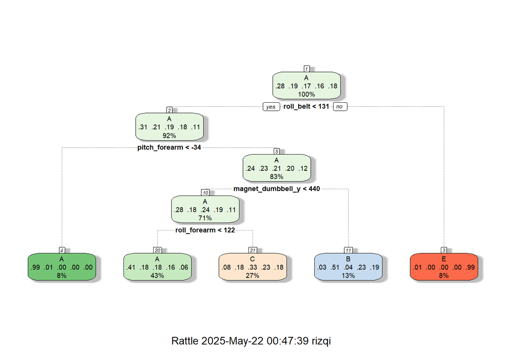

```r
set.seed(1234)
model_rpart <- train(classe ~ ., data = training_set, method = "rpart")
fancyRpartPlot(model_rpart$finalModel)  # Optional: visualize tree (if rattle package installed)
```

- Evaluate on validation set:

```r
pred_rpart <- predict(model_rpart, newdata = validation_set)
confusionMatrix(pred_rpart, validation_set$classe)
```

```
## Confusion Matrix and Statistics
##
##           Reference
## Prediction    A    B    C    D    E
##          A 1519  473  484  451  156
##          B   28  401   45  167  148
##          C  123  265  497  346  289
##          D    0    0    0    0    0
##          E    4    0    0    0  489
##
## Overall Statistics
##
##                Accuracy : 0.4938
##                  95% CI : (0.4809, 0.5067)
##     No Information Rate : 0.2845
##     P-Value [Acc > NIR] : < 2.2e-16
##
##                   Kappa : 0.338
##
##  Mcnemar's Test P-Value : NA
##
## Statistics by Class:
##
##                      Class: A Class: B Class: C Class: D Class: E
## Sensitivity            0.9074  0.35206  0.48441   0.0000  0.45194
## Specificity            0.6286  0.91825  0.78946   1.0000  0.99917
## Pos Pred Value         0.4927  0.50824  0.32697      NaN  0.99189
## Neg Pred Value         0.9447  0.85518  0.87881   0.8362  0.89002
## Prevalence             0.2845  0.19354  0.17434   0.1638  0.18386
## Detection Rate         0.2581  0.06814  0.08445   0.0000  0.08309
## Detection Prevalence   0.5239  0.13407  0.25828   0.0000  0.08377
## Balanced Accuracy      0.7680  0.63516  0.63693   0.5000  0.72555
```

- Train a Random Forest Model

```r
set.seed(1234)
cl <- makePSOCKcluster(4)  # Use 4 cores or change depending on your CPU
registerDoParallel(cl)

set.seed(1234)
model_rf <- train(
  classe ~ .,
  data = training_set,
  method = "rf",
  trControl = trainControl(method = "cv", number = 3),  # Reduce to 3-fold CV
  ntree = 100                                           # Reduce number of trees
)

stopCluster(cl)
```

- Evaluate on validation set:

```r
pred_rf <- predict(model_rf, newdata = validation_set)
confusionMatrix(pred_rf, validation_set$classe)
```

```
## Confusion Matrix and Statistics
##
##           Reference
## Prediction    A    B    C    D    E
##          A 1674    3    0    0    0
##          B    0 1134    4    0    0
##          C    0    2 1022    4    0
##          D    0    0    0  959    0
##          E    0    0    0    1 1082
##
## Overall Statistics
##
##                Accuracy : 0.9976
##                  95% CI : (0.996, 0.9987)
##     No Information Rate : 0.2845
##     P-Value [Acc > NIR] : < 2.2e-16
##
##                   Kappa : 0.997
##
##  Mcnemar's Test P-Value : NA
##
## Statistics by Class:
##
##                      Class: A Class: B Class: C Class: D Class: E
## Sensitivity            1.0000   0.9956   0.9961   0.9948   1.0000
## Specificity            0.9993   0.9992   0.9988   1.0000   0.9998
## Pos Pred Value         0.9982   0.9965   0.9942   1.0000   0.9991
## Neg Pred Value         1.0000   0.9989   0.9992   0.9990   1.0000
## Prevalence             0.2845   0.1935   0.1743   0.1638   0.1839
## Detection Rate         0.2845   0.1927   0.1737   0.1630   0.1839
## Detection Prevalence   0.2850   0.1934   0.1747   0.1630   0.1840
## Balanced Accuracy      0.9996   0.9974   0.9974   0.9974   0.9999
```

Step 5: Predict on the Test Set

The test dataset (testing_clean) contains 20 samples, and the final job is to use the best model to predict the class (classe) for each of them.

- Make Predictions on the Test Set

```r
final_predictions <- predict(model_rf, newdata = testing_clean)
final_predictions
```

```
##  [1] B A B A A E D B A A B C B A E E A B B B
## Levels: A B C D E
```

Conclusion

Random Forest had the highest accuracy and was used for the final prediction.